# Examine Tuning Parameters

Kevin Lu

November 20, 2017

# 1. Load Packages

```r
source("./Mean Reversion/RMR.001 Load Packages.R")
```

# 2. Load Data

```r
params <- read_csv("./Mean Reversion/Output/Parameter Tuning/parameter tuning 20171030.csv")
```

# 3. Remove Bug and Outliers

This set of parameters had a bug that affected runs where the pair allocation was set to scaled. These observations are removed.

```r
single <- params %>%
  filter(pair_allocation != "scaled",
         overall_return <= 5,
         overall_return >= 0) %>%
  mutate(train_window = as.numeric(str_match(train_window, "(\\d*)d*")[, 2]),
         test_window = as.numeric(str_match(test_window, "(\\d*)d*")[, 2]),
         model_spread_type = str_c(model_type, " ", spread_type),
         rolling_window_days = rolling_window * time_resolution / 60 / 60 / 24,
         time_resolution = factor(time_resolution),
         signal_scaled_enter = factor(signal_scaled_enter))
```

# 4. Plot Functions

```r
plot_boxplot <- function(df, x, ylim_low, ylim_high) {
  ggplot(df, aes_string(x = x, fill = x)) +
    geom_boxplot(aes(y = overall_return)) +
    coord_cartesian(ylim = c(ylim_low, ylim_high)) +
    facet_wrap(~ quote_currency, ncol = 1) +
    geom_hline(yintercept = 1)
}

plot_scatter <- function(df, x, ylim_low, ylim_high, smooth) {
  if (smooth == TRUE) {
    return(ggplot(df, aes_string(x = x)) +
             geom_point(aes(y = overall_return), colour = "blue") +
             geom_smooth(aes(y = overall_return), colour = "red") +
             coord_cartesian(ylim = c(ylim_low, ylim_high)) +
             facet_wrap(~ quote_currency, ncol = 1) +
             geom_hline(yintercept = 1))
  }
  if (smooth == FALSE) {
    return(ggplot(df, aes_string(x = x)) +
             geom_point(aes(y = overall_return), colour = "blue") +
             coord_cartesian(ylim = c(ylim_low, ylim_high)) +
             facet_wrap(~ quote_currency, ncol = 1) +
             geom_hline(yintercept = 1))
  }
}
```

# 5. Examine Single Parameters

This section creates plots that examine only one parameter at a time.

## 5.1 Time Resolution

Time resolution of 300 is the best performing time resolution.

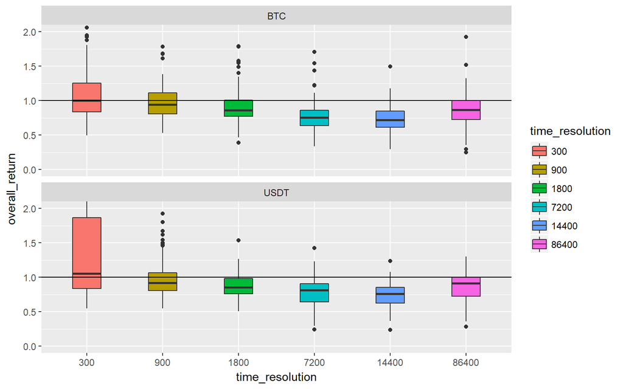

```r
plot_boxplot(single, "time_resolution", 0, 2)
```

## 5.2 Quote Currency

Similar cumulative return for BTC quote-denominated and USDT quote-denominated coin pairs except that BTC coin pairs have a return relative to the buy-and-hold return of holindg BTC.

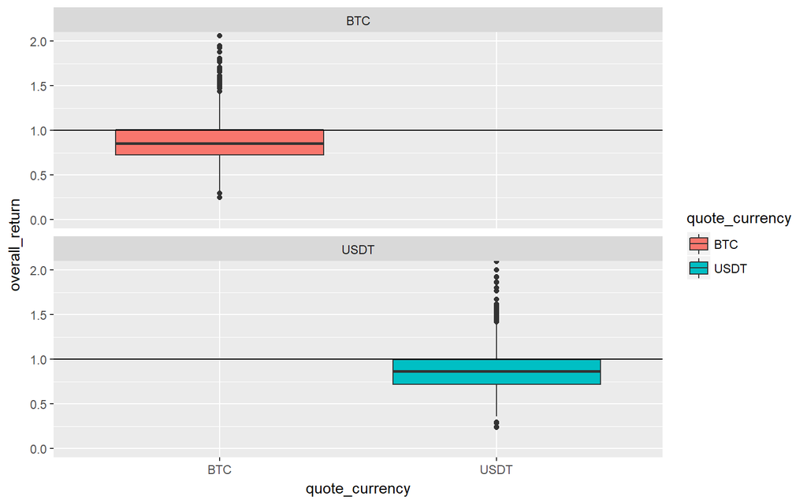

```r
plot_boxplot(single, "quote_currency", 0, 2)
```

## 5.3 Cointegration Test

Similar cumulative return for both types of cointegration tests.

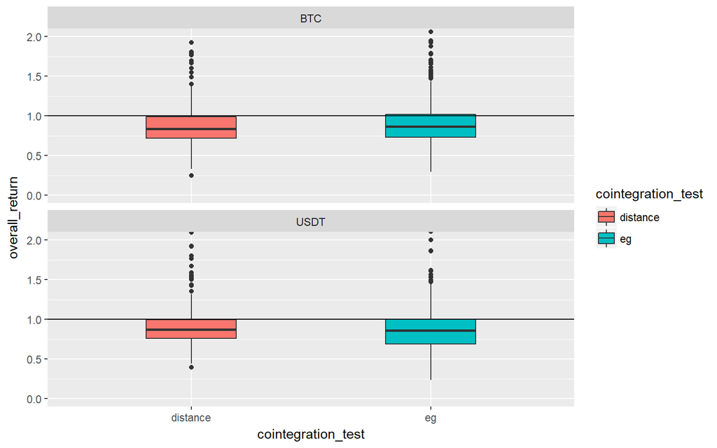

```r
plot_boxplot(single, "cointegration_test", 0, 2)
```

## 5.4 ADF and Distance Threshold

Higher returns associated with more restrictive ADF threshold.  
Higher returns associated with more restrictive distance threshold.

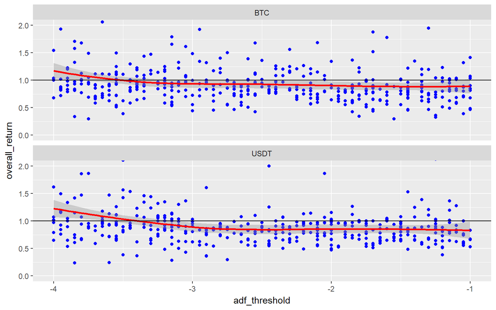

```r
single %>%
  filter(cointegration_test == "eg") %>%
  plot_scatter("adf_threshold", 0, 2, TRUE)
```

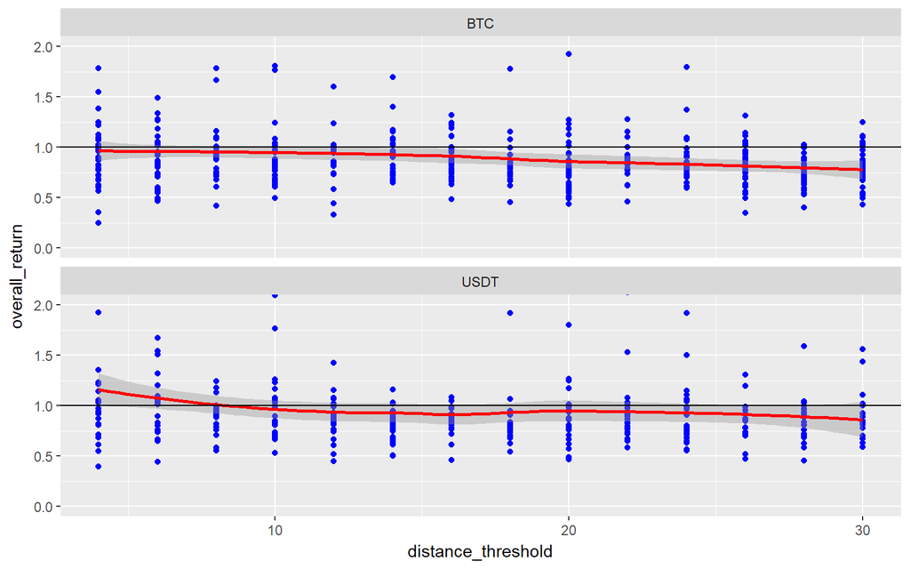

```r
single %>%
  filter(cointegration_test == "distance") %>%
  plot_scatter("distance_threshold", 0, 2, TRUE)
```

## 5.5 Train and Test Window

Slightly better performance with shorter test window.

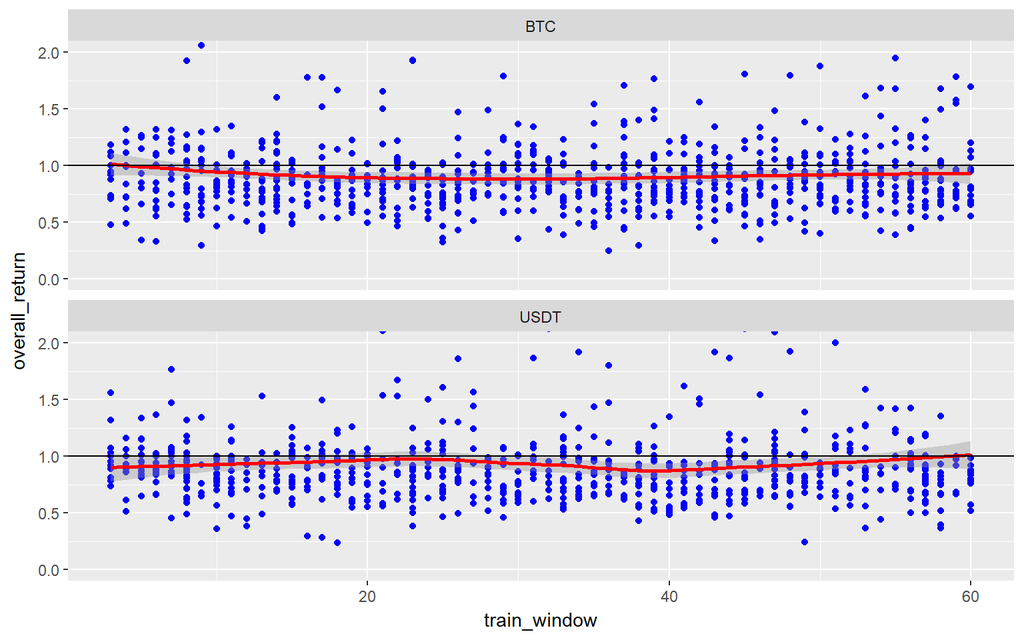

```r
plot_scatter(single, "train_window", 0, 2, TRUE)
```

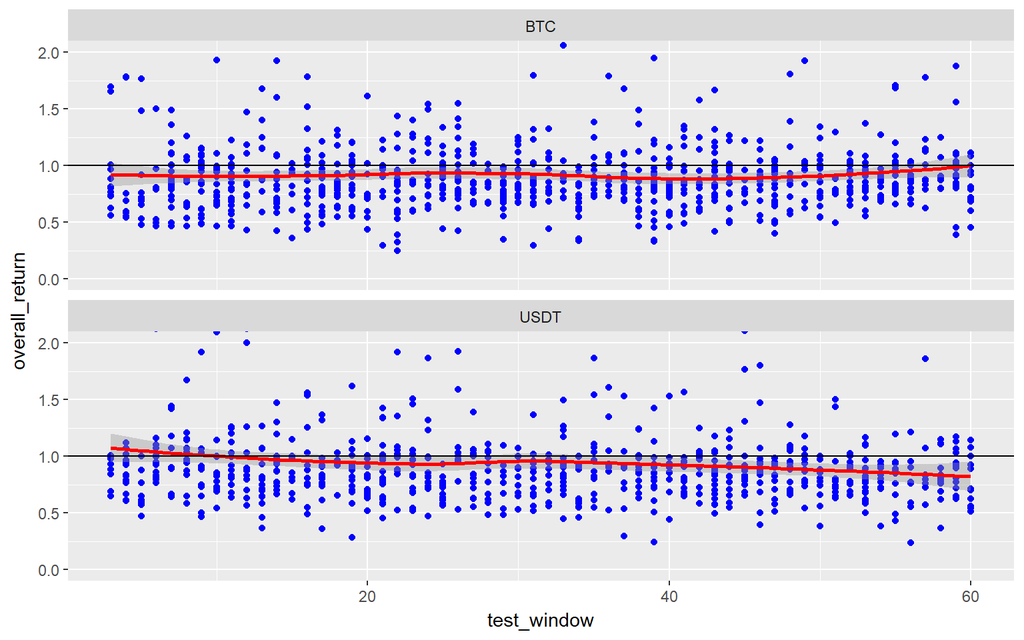

```r
plot_scatter(single, "test_window", 0, 2, TRUE)
```

## 5.6 Model and Spread Type

Higher returns associated with log model type.  
Higher returns associated with rolling spread type.

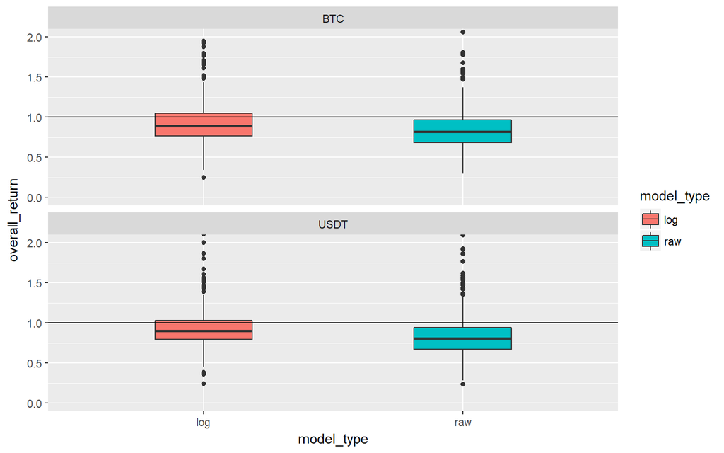

```r
plot_boxplot(single, "model_type", 0, 2)
```

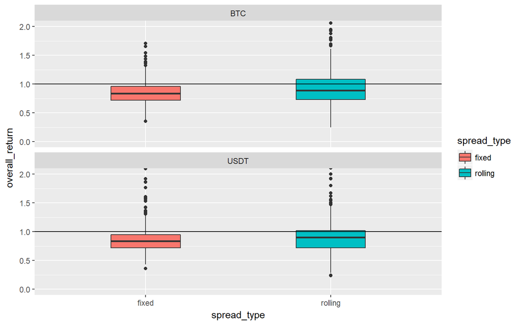

```r
plot_boxplot(single, "spread_type", 0, 2)
```

## 5.7 Rolling Window

Higher returns associated with shorter rolling windows.

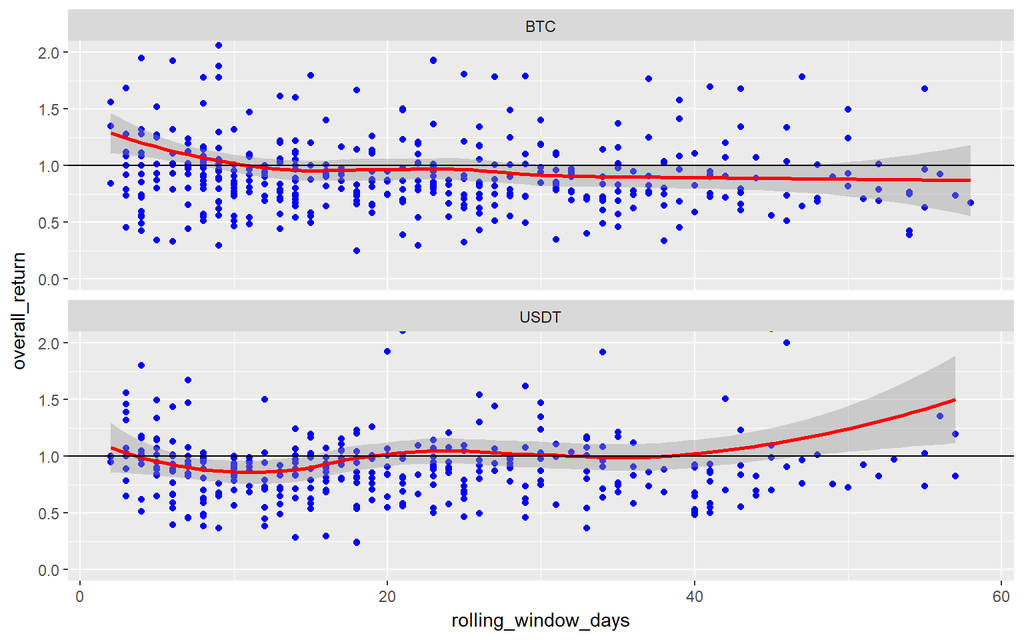

```r
single %>%
  filter(spread_type == "rolling") %>%
  plot_scatter("rolling_window_days", 0, 2, TRUE)
```

## 5.8 Signal Logic

Higher returns associated with scaled signal logic.  
Slightly higher returns associated with signal scaled enter of 3.  
Slightly higher returns associated with higher signal discrete enter. Slightly higher returns associated with higher signal discrete exit.  
No pattern associated with signal stop.  
Higher returns associated with signal reenter of FALSE.  
Slightly higher returns associated with a lower signal reenter threshold.

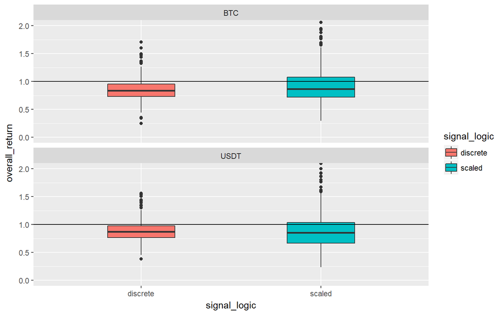

```r
plot_boxplot(single, "signal_logic", 0, 2)
```

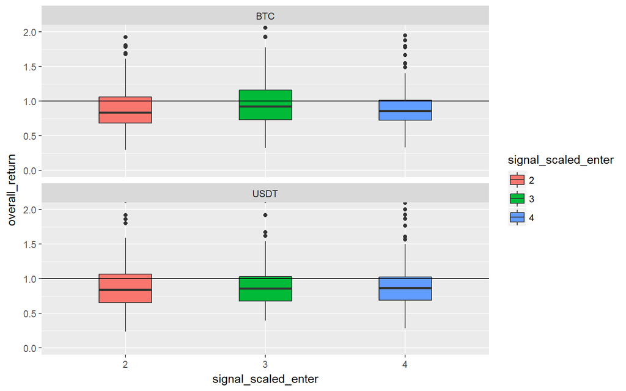

```r
single %>%
  filter(signal_logic == "scaled") %>%
  plot_boxplot("signal_scaled_enter", 0, 2)
```

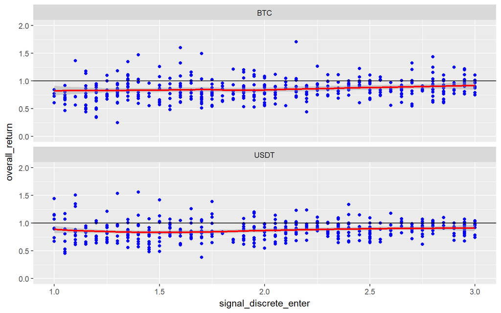

```r
single %>%
  filter(signal_logic == "discrete") %>%
  plot_scatter("signal_discrete_enter", 0, 2, TRUE)
```

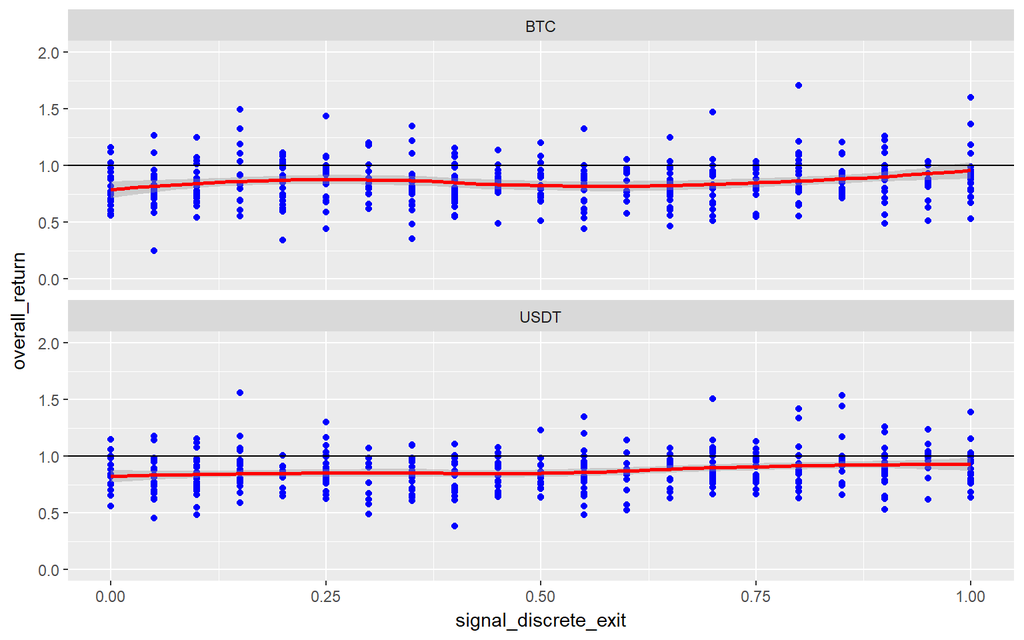

```r
single %>%
  filter(signal_logic == "discrete") %>%
  plot_scatter("signal_discrete_exit", 0, 2, TRUE)
```

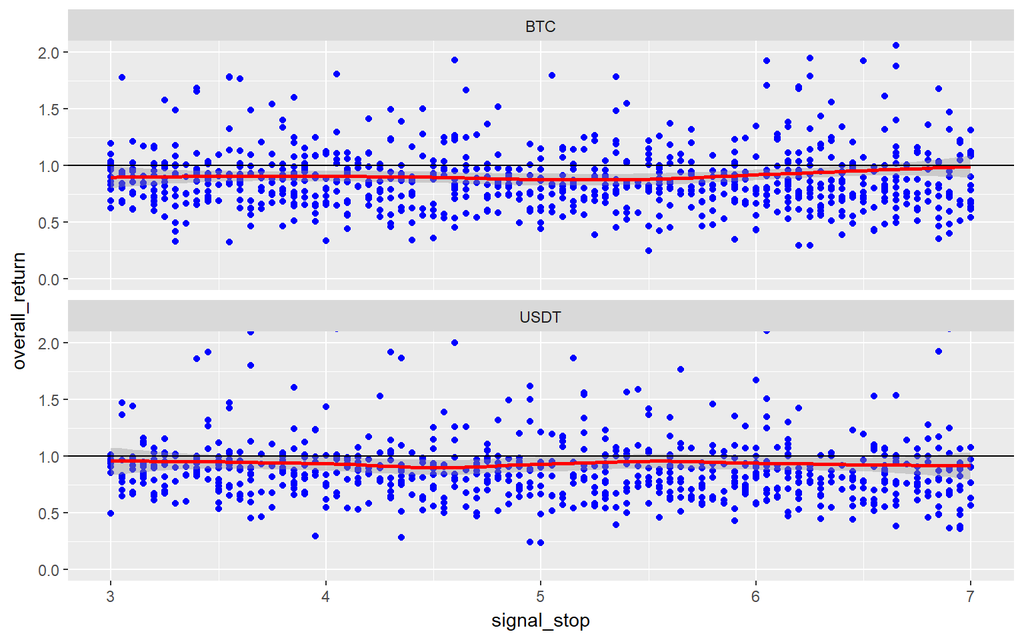

```r
plot_scatter(single, "signal_stop", 0, 2, TRUE)
```

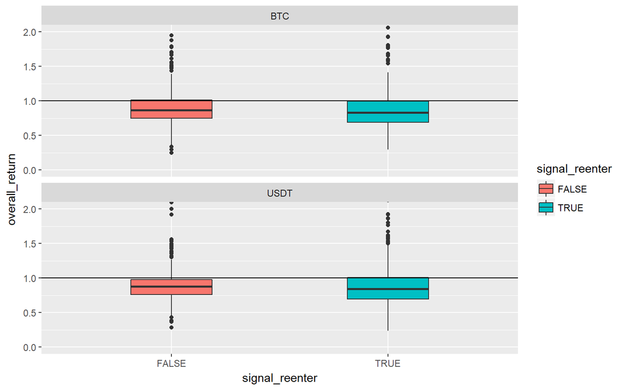

```r
plot_boxplot(single, "signal_reenter", 0, 2)
```

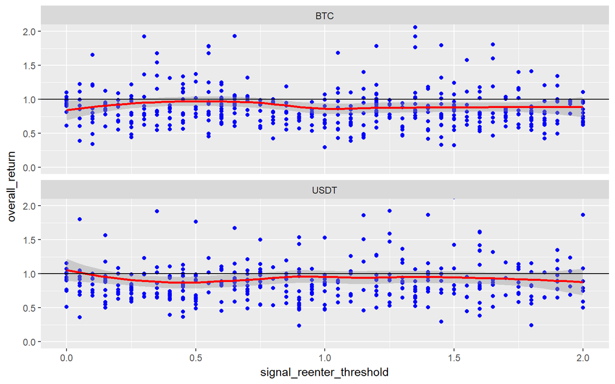

```r
single %>%
  filter(signal_reenter == TRUE) %>%
  plot_scatter("signal_reenter_threshold", 0, 2, TRUE)
```

## 5.9 Pair Allocation

Slightly higher returns associated with a weighted pair allocation.

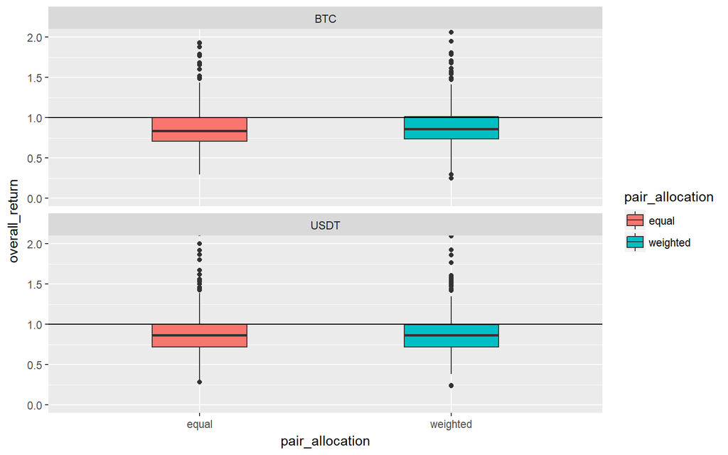

```r
plot_boxplot(single, "pair_allocation", 0, 2)
```

# 6. Examine Multiple Parameters

This section creates plots that examines multiple parameters at a time for iterations where the time resolution is 300, the spread type is rolling, and the signal logic is scaled. These parameters have shown to have produced good results.

```r
params <- bind_rows(read_csv("./Mean Reversion/Output/Parameter Tuning/parameter tuning 20171101.csv"),
                    read_csv("./Mean Reversion/Output/Parameter Tuning/parameter tuning 20171102.csv"),
                    read_csv("./Mean Reversion/Output/Parameter Tuning/parameter tuning 20171106.csv"),
                    read_csv("./Mean Reversion/Output/Parameter Tuning/parameter tuning 20171113.csv"))
```

## 6.1 Filter Results

Iterations with an overall return greater than 20 are removed. This removes 49 out of the 1146 iterations but makes the smoothing much more interpretable.

```r
multiple <- params %>%
  filter(time_resolution == 300,
         spread_type == "rolling",
         signal_logic == "scaled") %>%
  mutate(train_window = as.numeric(str_match(train_window, "(\\d*)d*")[, 2]),
         test_window = as.numeric(str_match(test_window, "(\\d*)d*")[, 2]),
         model_spread_type = str_c(model_type, " ", spread_type),
         rolling_window_days = rolling_window * time_resolution / 60 / 60 / 24,
         time_resolution = factor(time_resolution),
         signal_scaled_enter = factor(signal_scaled_enter)) %>%
  filter(overall_return <= 20)
print(multiple)
```

```
## # A tibble: 1,097 x 23
##    time_resolution quote_currency cointegration_test adf_threshold
##             <fctr>          <chr>              <chr>         <dbl>
##  1             300           USDT                 eg         -2.15
##  2             300           USDT                 eg         -2.95
##  3             300           USDT                 eg         -3.20
##  4             300            BTC                 eg         -2.40
##  5             300           USDT                 eg         -2.65
##  6             300           USDT                 eg         -2.60
##  7             300           USDT                 eg         -2.30
##  8             300           USDT                 eg         -3.10
##  9             300           USDT                 eg         -2.50
## 10             300           USDT                 eg         -4.00
## # ... with 1,087 more rows, and 19 more variables:
## #   distance_threshold <dbl>, train_window <dbl>, test_window <dbl>,
## #   model_type <chr>, spread_type <chr>, rolling_window <int>,
## #   signal_logic <chr>, signal_scaled_enter <fctr>,
## #   signal_discrete_enter <dbl>, signal_discrete_exit <dbl>,
## #   signal_stop <dbl>, signal_reenter <lgl>,
## #   signal_reenter_threshold <dbl>, pair_allocation <chr>,
## #   pair_allocation_scaling <dbl>, overall_return <dbl>,
## #   regression_type <chr>, model_spread_type <chr>,
## #   rolling_window_days <dbl>
```

## 6.2 Cointegration Test

Higher returns associated with the engle-granger cointegration test.

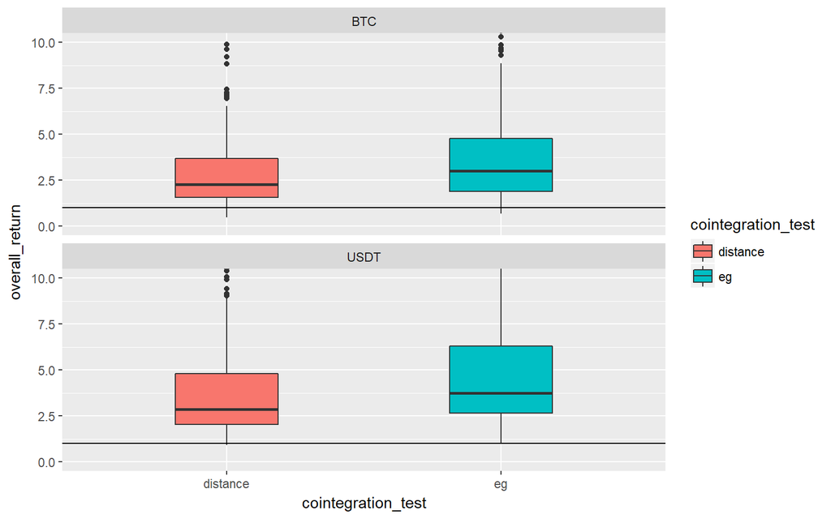

```r
plot_boxplot(multiple, "cointegration_test", 0, 10)
```

## 6.3 ADF and Distance Threshold

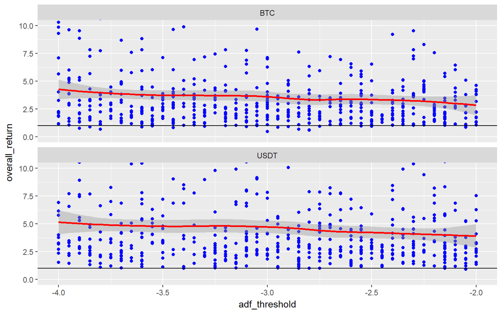

```r
plot_scatter(multiple, "adf_threshold", 0, 10, TRUE)
```

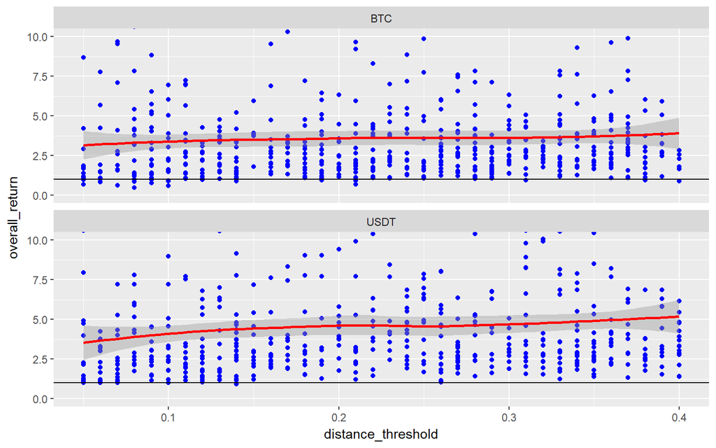

```r
plot_scatter(multiple, "distance_threshold", 0, 10, TRUE)
```

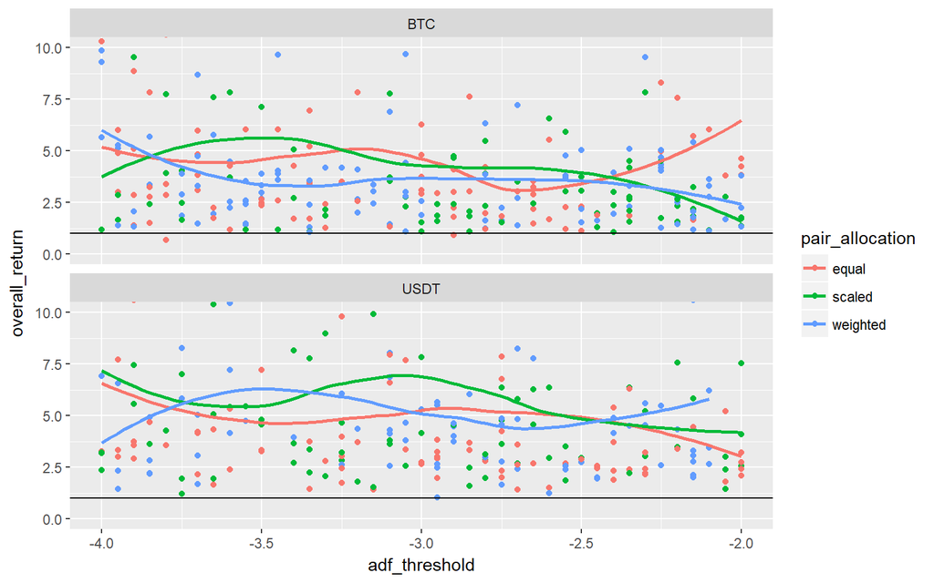

```r
multiple %>%
  filter(cointegration_test == "eg") %>%
  ggplot(aes(x = adf_threshold, y = overall_return, colour = pair_allocation)) +
  coord_cartesian(ylim = c(0, 10)) +
  geom_point() +
  geom_smooth(se = FALSE) +
  geom_hline(yintercept = 1) +
  facet_wrap(~ quote_currency, ncol = 1)
```

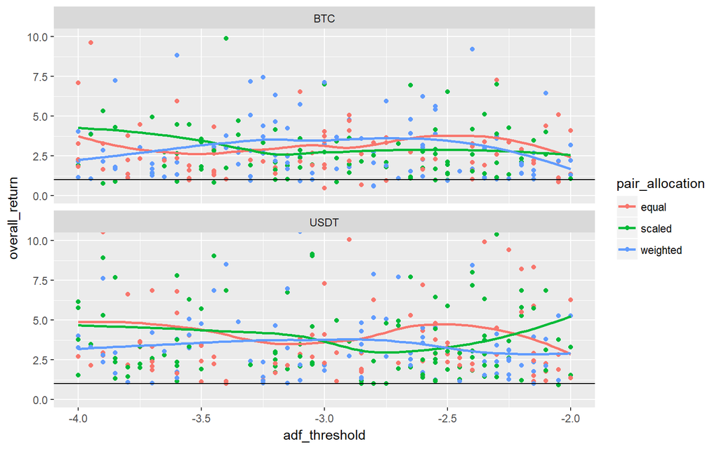

```r
multiple %>%
  filter(cointegration_test == "distance") %>%
  ggplot(aes(x = adf_threshold, y = overall_return, colour = pair_allocation)) +
  coord_cartesian(ylim = c(0, 10)) +
  geom_point() +
  geom_smooth(se = FALSE) +
  geom_hline(yintercept = 1) +
  facet_wrap(~ quote_currency, ncol = 1)
```

## 6.4 Train and Test Window

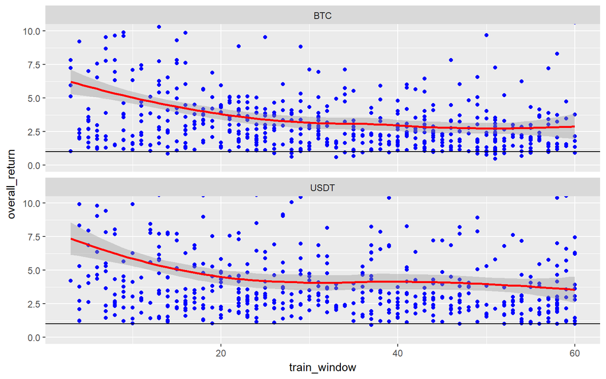

```r
plot_scatter(multiple, "train_window", 0, 10, TRUE)
```

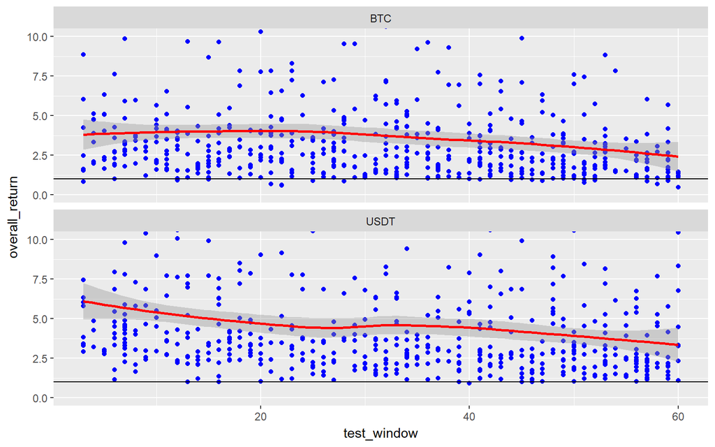

```r
plot_scatter(multiple, "test_window", 0, 10, TRUE)
```

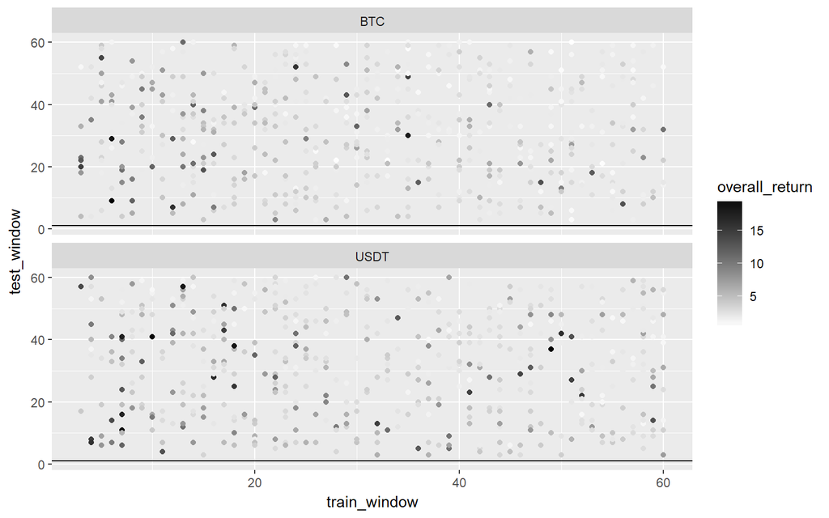

```r
multiple %>%
  ggplot(aes(x = train_window, y = test_window, colour = overall_return)) +
  geom_point() +
  scale_colour_gradient(low = "white", high = "black") +
  geom_hline(yintercept = 1) +
  facet_wrap(~ quote_currency, ncol = 1)
```

## 6.5 Model Type and ADF Threshold and Distance Threshold

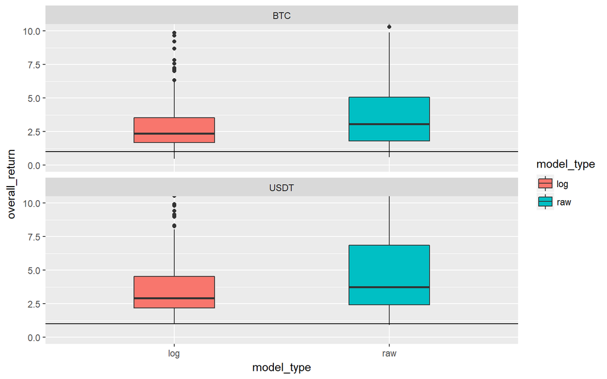

```r
plot_boxplot(multiple, "model_type", 0, 10)
```

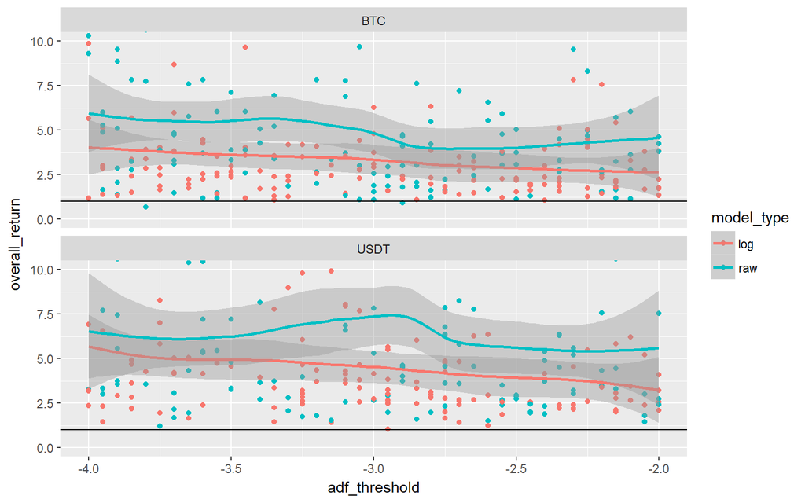

```r
multiple %>%
  filter(cointegration_test == "eg") %>%
  ggplot(aes(x = adf_threshold, y = overall_return, colour = model_type)) +
  coord_cartesian(ylim = c(0, 10)) +
  geom_point() +
  geom_smooth() +
  geom_hline(yintercept = 1) +
  facet_wrap(~ quote_currency, ncol = 1)
```

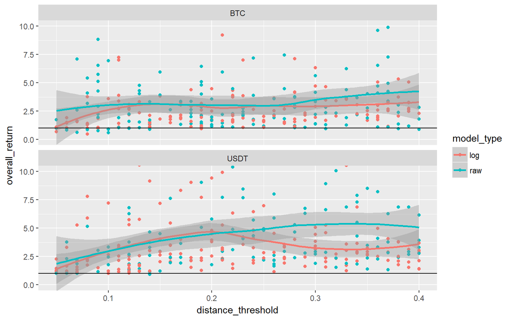

```r
multiple %>%
  filter(cointegration_test == "distance") %>%
  ggplot(aes(x = distance_threshold, y = overall_return, colour = model_type)) +
  coord_cartesian(ylim = c(0, 10)) +
  geom_point() +
  geom_smooth() +
  geom_hline(yintercept = 1) +
  facet_wrap(~ quote_currency, ncol = 1)
```

## 6.6 Rolling Window

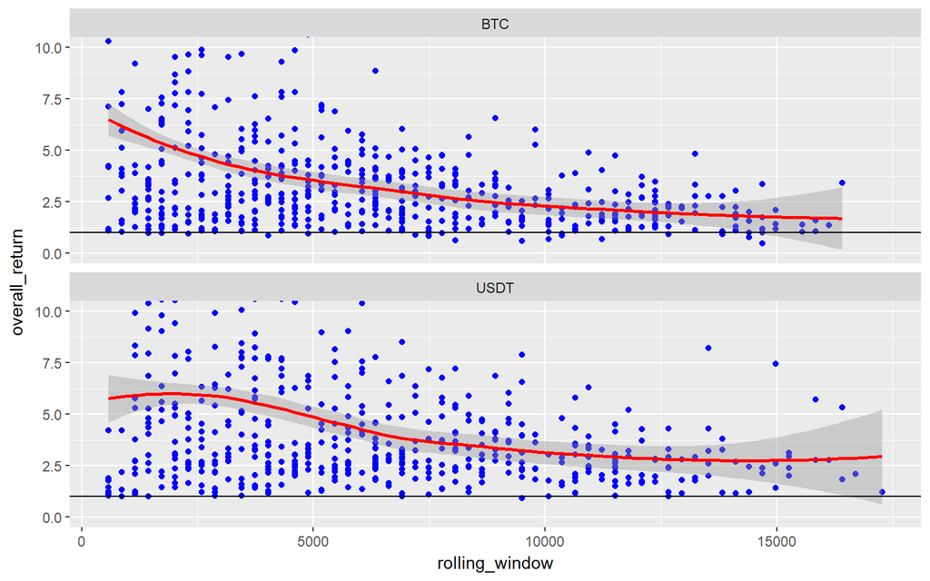

```r
plot_scatter(multiple, "rolling_window", 0, 10, TRUE)
```

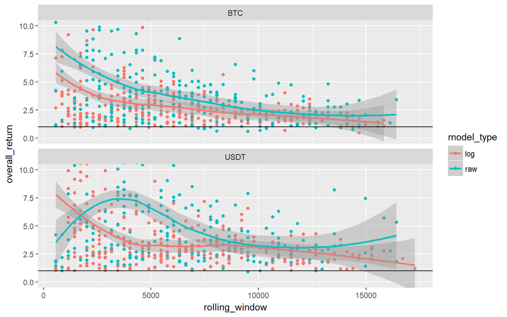

```r
multiple %>%
  ggplot(aes(x = rolling_window, y = overall_return, colour = model_type)) +
  coord_cartesian(ylim = c(0, 10)) +
  geom_point() +
  geom_smooth() +
  geom_hline(yintercept = 1) +
  facet_wrap(~ quote_currency, ncol = 1)
```

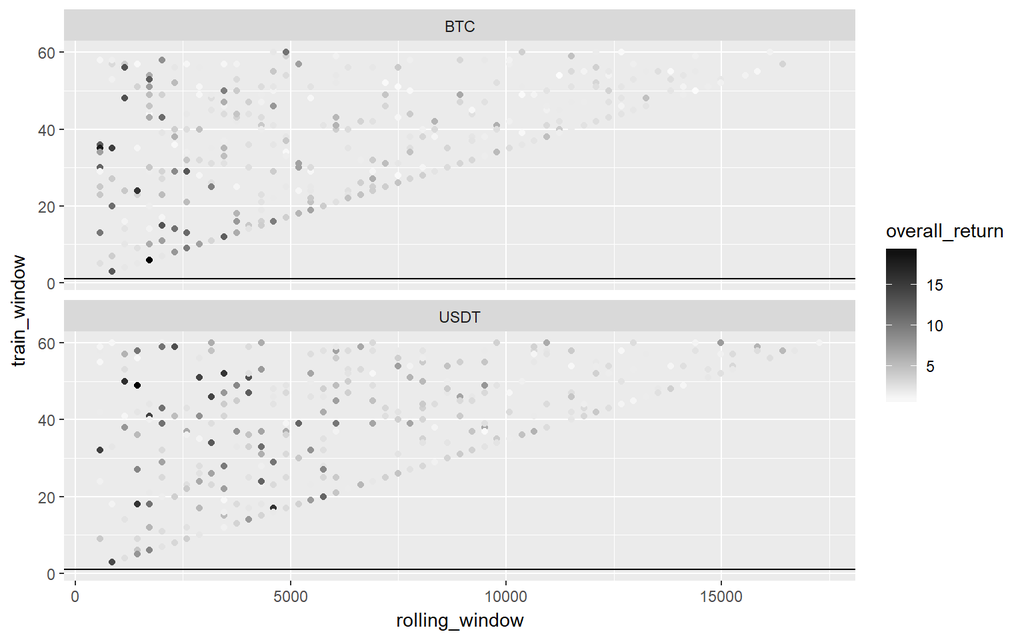

```r
multiple %>%
  ggplot(aes(x = rolling_window, y = train_window, colour = overall_return)) +
  geom_point() +
  scale_colour_gradient(low = "white", high = "black") +
  geom_hline(yintercept = 1) +
  facet_wrap(~ quote_currency, ncol = 1)
```